# Problem Set 09

WRITE YOUR NAME HERE

Due Friday, November 18, 2016

Investigate whether economics majors did better than all other majors on the final exam for my intro stats class back in the day. Tweak the code from `Lec25.R`.

```r
library(ggplot2)
library(dplyr)
library(mosaic)
library(readr)

# Set see value
set.seed(76)

# Copy the code that loads grades.csv into RStudio here.
# Note you will need to change this line to whatever loads the data for you:
grades <- read_csv("../PS/grades.csv")
```

## Exploratory Data Analysis

It is not immediately apparent if one did better:

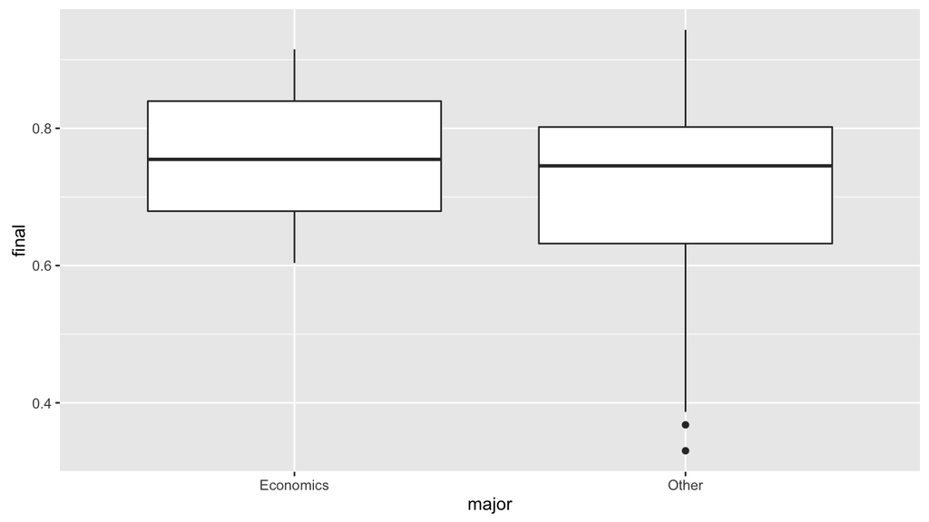

```r
ggplot(data=grades, aes(x=major, y=final)) +
  geom_boxplot()
```

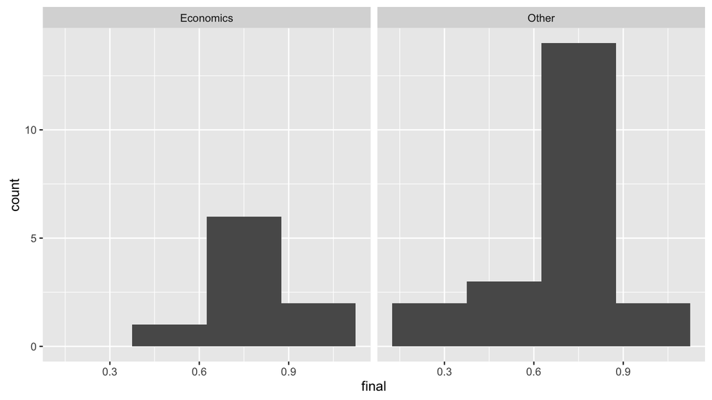

```r
ggplot(data=grades, aes(x=final)) +
  geom_histogram(binwidth = 0.25) +
  facet_wrap(~major)
```

**Important**: We have to be very careful to note if we are subtracting:

- `Other-Economics`
- `Economics-Other`

and be consistent. It seems we are doing `Other-Economics`:

```r
mean(final ~ major, data=grades)
```

```
## Economics     Other
## 0.7599581 0.6823899
```

```r
mean(final ~ major, data=grades) %>% diff()
```

```
##       Other
## -0.07756813
```

Econ majors did about 7.8% better on average.

## Hypothesis Test

We proceed with the hypothesis test

- $H_0$: econ and other majors did equally well i.e. no difference
- $H_A$: i.e. there is a difference

Recall that under $H_0$, since there is no difference between the two groups, the variable `major` is meaningless, so we can permute/shuffle it around and it doesn’t matter:

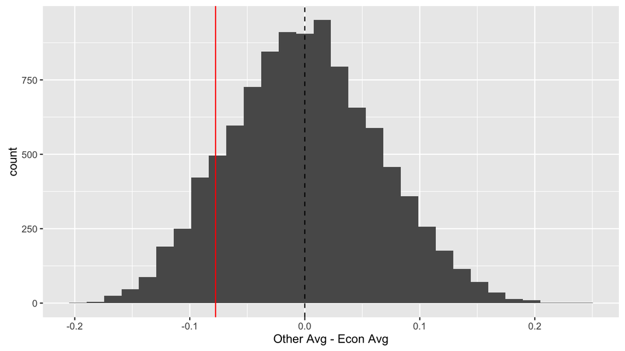

```r
# Compute observed test statistic
observed_diff <- mean(final ~ major, data=grades) %>% diff()

# Simulate the null distribution of the test statistic:
simulations <- do(10000) * mean(final ~ shuffle(major), data=grades)
simulations <- simulations %>%
  as_data_frame() %>%
  mutate(difference=Other-Economics)

# Compare what we observed (red) to what happens if we assume no difference:
ggplot(data=simulations , aes(x=difference)) +
  geom_histogram() +
  geom_vline(xintercept = observed_diff, col="red") +
  geom_vline(xintercept = 0, linetype="dashed") +
  labs(x="Other Avg - Econ Avg")
```

## Conclusion

IMO I wouldn’t say Econ did significantly better. We fail to reject $H_0$ that they did equally well. i.e. Maybe one group is in fact better than the other, but we don’t have evidence to suggest that here.

**Note**: this was an example of a *two-sided two-sample permutation test for differences in means*

1. two-sided: type of alternative hypothesis
2. two-sample: i.e there are two groups
3. permutation test: we constructed the null distribution via permutations/simulations
4. difference in means: comparing means

More on these options on Monday.

## p-Value

The p-value is the probability of observing a test statistic just as or more extreme than the one observed. In our case since $H_A: \mu_{other} - \mu_{econ} \neq 0$: i.e. there is a difference, we can have either

- A more extreme negative difference
- A more extreme positive difference

```r
simulations %>%
  mutate(more_extreme_left = difference <= observed_diff) %>%
  summarise(more_extreme_left = sum(more_extreme_left))
```

```
## # A tibble: 1 × 1
##   more_extreme_left
##               <int>
## 1              1181
```

There are 1181 values less than the observed difference of -7.8%. So the p-value is

$$\frac{2 \times 1181 + 1}{10000 + 1} = 0.236$$
**Notes**:

1. Note we doubled the 1181 because we have a two-sided alternative $H_A: \mu_{other} - \mu_{econ} \neq 0$
2. We add 1 to both the numerator and denominator since we also need to account for the observed test statistic itself

## Other Alternatives

- Say we had $H_A: \mu_{other} - \mu_{econ} < 0$, more extreme would mean more negative, i.e. more to the left of the observed test statistic, i.e. the p-value would be
  $$\frac{1181 + 1}{10000 + 1} = 0.118$$
- Say we had $H_A: \mu_{other} - \mu_{econ} > 0$, more extreme would mean more positive, i.e. more to the right of the observed test statistic, i.e. the p-value would be
  $$\frac{(10000-1181) + 1}{10000 + 1} = 0.882$$